# Data transformation (I)

Create new variables, filter, select and organize data

## Reducing variables: `summarise` or `summarize`

Data manipulation means different things to different researchers. Sometimes we want to select certain observations (rows) or variables (columns), other times we want to group the data according to one or more variables, or we want to calculate statistical values from according to a grouping or category scheme.

The funtion `summarise` allows to calculate statiscal aggregation of one or more variables.

[figure not shown]

We can leverage common statistical/summary functions to summarize numerical variables:

```r
summarise(trees, mean_if3 = mean(DiamIf3))
```

```
## # A tibble: 1 x 1
##   mean_if3
##      <dbl>
## 1     23.4
```

2. Actually, the `mean` means nothing without the standard deviation. Fortunately, we can concatenate summaries just using `,` to implement additional summaries:

```r
summarise(trees, mean_if3 = mean(DiamIf3), sd_if3 = sd(DiamIf3))
```

```
## # A tibble: 1 x 2
##   mean_if3 sd_if3
##      <dbl>  <dbl>
## 1     23.4   10.3
```

## Grouped summaries: `group_by`

The summary of a variable is important to have an idea about the data. However, summarizing a variable by group gives better information on the distribution of the data. In fact, one of the most common ways in which we create summaries is by grouping on the basis of certain information. That means, we split observations between a number of groups and the calculate the summary statistics.

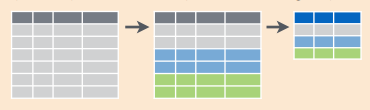

Grouped summaries enable the comparison of the behavior of a given variable across categories. Groups can be either numerical or categorical variables, though the second are often more suitable and straightforward towards visualization and plotting.

1. Let’s group `trees` at province level:

```r
unique(trees$Provincia)
```

```
## [1] "08" "17" "25" "43"
```

```r
by_province <- group_by(trees, Provincia)
by_province
```

```
## # A tibble: 111,756 x 10
## # Groups:   Provincia [4]
##    Codi   Provincia Especie Rumbo  Dist      N    CD DiamIf3 DiamIf2 HeiIf3
##    <fct>  <chr>     <fct>   <dbl> <dbl>  <dbl> <dbl>   <dbl>   <dbl>  <dbl>
##  1 080001 08        022         7  8.3   31.8     20    20.3    18.9    9
##  2 080002 08        476        38  9.1   31.8     35    34      32.4    9
##  3 080003 08        021        25  7     31.8     25    24.8    17.6   11
##  4 080004 08        021        28  8.89  31.8     15    16.8    12.6    9.5
##  5 080006 08        021        19 11.2   14.1     35    34.0    30.9   13
##  6 080007 08        021        32 12     14.1     35    33.1    28.2   10
##  7 080008 08        243        40  7.8   31.8     15    15      13.2    6
##  8 080009 08        045        16  5.09  31.8     20    17.5    15.3    7
##  9 080010 08        243        47 26.9    5.09    65    67.4    66.8   16.5
## 10 080013 08        022        44  2.7  127.      15    15.1    12.6    9.5
## # ... with 111,746 more rows
```

2. Now we can apply `summarise` to get an aggregation value per group category:

```r
summarise(
  by_province,
  mean_height_ifn3 = mean(HeiIf3, na.rm = TRUE),
  max_height_ifn3 = max(HeiIf3, na.rm = TRUE),
  min_height_ifn3 = min(HeiIf3, na.rm = TRUE)
)
```

```
## # A tibble: 4 x 4
##   Provincia mean_height_ifn3 max_height_ifn3 min_height_ifn3
##   <chr>                <dbl>           <dbl>           <dbl>
## 1 08                   11.2             35               1.6
## 2 17                   11.4             38               1.5
## 3 25                   11.4             35.8             2
## 4 43                    9.21            33               2
```

3. Of course, we can concatenate `group_by` and `summarise` using `pipes`:

```r
trees %>%
    group_by(Provincia) %>%
    summarise(
          mean_height_ifn3 = mean(HeiIf3, na.rm = TRUE),
          max_height_ifn3 = max(HeiIf3, na.rm = TRUE),
          min_height_ifn3 = min(HeiIf3, na.rm = TRUE)
        )
```

```
## # A tibble: 4 x 4
##   Provincia mean_height_ifn3 max_height_ifn3 min_height_ifn3
##   <chr>                <dbl>           <dbl>           <dbl>
## 1 08                   11.2             35               1.6
## 2 17                   11.4             38               1.5
## 3 25                   11.4             35.8             2
## 4 43                    9.21            33               2
```

4. We must bear in mind that we can apply **any function** to that fits the structure of the data. For instance, we can calculate per group correlation coefficients:

```r
summarise(
  by_province,
  R = cor(HeiIf3, DiamIf3)
)
```

```
## # A tibble: 4 x 2
##   Provincia     R
##   <chr>     <dbl>
## 1 08        0.621
## 2 17        0.600
## 3 25        0.646
## 4 43        0.700
```

**Exercise 5**

```
  5.1 Which species showed the largest increase in diameter between IFN2 and IFN3?

  5.2 Which province gather the largest number of species?
```

## Targeted summaries

### `summarise_if` and `summarise_at`

We can apply a summarising function to a group of variables that share some commmon characteristics that can be tested (i.e. numeric variables).

1. `summarise_if` applies the selected function to those variables that meet a condition. For instance, we can get the `mean` of any variable (columnn) containting numerical data:

```r
summarise_if(trees, is.numeric, mean)
```

```
## # A tibble: 1 x 7
##   Rumbo  Dist     N    CD DiamIf3 DiamIf2 HeiIf3
##   <dbl> <dbl> <dbl> <dbl>   <dbl>   <dbl>  <dbl>
## 1  198.  7.78  55.6  23.4    23.4    20.3   11.1
```

2. With `summarise_at` we can limit the summary by name or using the select helpers (`starts_with`, `ends_with`, `one_of`).

```r
summarise_at(trees, vars(starts_with('Diam')), mean)
```

```
## # A tibble: 1 x 2
##   DiamIf3 DiamIf2
##     <dbl>   <dbl>
## 1    23.4    20.3
```

## Targeted transformations

The same targeting approaches can be used with `mutate`:

1. Log-transform those columns containing numerical variable:

```r
mutate_if(trees, is.numeric, log)
```

```
## # A tibble: 111,756 x 10
##    Codi   Provincia Especie Rumbo  Dist     N    CD DiamIf3 DiamIf2 HeiIf3
##    <fct>  <chr>     <fct>   <dbl> <dbl> <dbl> <dbl>   <dbl>   <dbl>  <dbl>
##  1 080001 08        022      1.95 2.12   3.46  3.00    3.01    2.94   2.20
##  2 080002 08        476      3.64 2.21   3.46  3.56    3.53    3.48   2.20
##  3 080003 08        021      3.22 1.95   3.46  3.22    3.21    2.87   2.40
##  4 080004 08        021      3.33 2.18   3.46  2.71    2.82    2.54   2.25
##  5 080006 08        021      2.94 2.42   2.65  3.56    3.53    3.43   2.56
##  6 080007 08        021      3.47 2.48   2.65  3.56    3.50    3.34   2.30
##  7 080008 08        243      3.69 2.05   3.46  2.71    2.71    2.58   1.79
##  8 080009 08        045      2.77 1.63   3.46  3.00    2.86    2.73   1.95
##  9 080010 08        243      3.85 3.29   1.63  4.17    4.21    4.20   2.80
## 10 080013 08        022      3.78 0.993  4.85  2.71    2.71    2.53   2.25
## # ... with 111,746 more rows
```

2. Recode certain variables. Add *sp_* before the corresponding species code:

```r
mutate_at(
  trees, vars(one_of(c('Especie', 'Species'))),
  ~ paste0('sp_', .x)
)
```

```
## # A tibble: 111,756 x 10
##    Codi   Provincia Especie Rumbo  Dist      N    CD DiamIf3 DiamIf2 HeiIf3
##    <fct>  <chr>     <chr>   <dbl> <dbl>  <dbl> <dbl>   <dbl>   <dbl>  <dbl>
##  1 080001 08        sp_022      7  8.3   31.8     20    20.3    18.9    9
##  2 080002 08        sp_476     38  9.1   31.8     35    34      32.4    9
##  3 080003 08        sp_021     25  7     31.8     25    24.8    17.6   11
##  4 080004 08        sp_021     28  8.89  31.8     15    16.8    12.6    9.5
##  5 080006 08        sp_021     19 11.2   14.1     35    34.0    30.9   13
##  6 080007 08        sp_021     32 12     14.1     35    33.1    28.2   10
##  7 080008 08        sp_243     40  7.8   31.8     15    15      13.2    6
##  8 080009 08        sp_045     16  5.09  31.8     20    17.5    15.3    7
##  9 080010 08        sp_243     47 26.9    5.09    65    67.4    66.8   16.5
## 10 080013 08        sp_022     44  2.7  127.      15    15.1    12.6    9.5
## # ... with 111,746 more rows
```

**Exercise 6**

```
Create pipelines to answer the following questions:

  6.1 Which **plots** have the fastest average growth rate?

  6.2 Which is the plot with the **most species**?

  6.3 Is there any **relationship** between both variables? <br>
  *(Optional, some knowledge on `ggplot`is required)*
```

## Grouped `mutate`/`filter`

We will commonly use groups (`group_by`) when summarising variables (*n* inputs, one output):

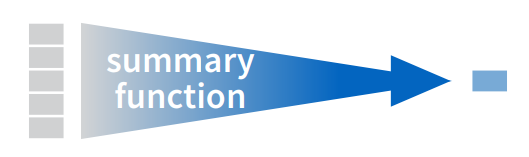

```r
group_by(Especie) %>% summarise(mean = mean(Diam))
```

Sometimes, however, we may be interested in calculating new variables by group, but without reducing the dimensions:

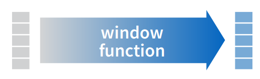

1. In this example we calculate the difference between the diameter of each tree and the average value of the trees of the same species. `DiamIf3` is taken rowwise whereas the `mean` is calculated at species (*Especie*) level thanks to `group_by`.

```r
trees %>%
  group_by(Especie) %>%
  mutate(
    std_diam = DiamIf3 - mean(DiamIf3)
  )
```

```
## # A tibble: 111,756 x 11
## # Groups:   Especie [91]
##    Codi   Provincia Especie Rumbo  Dist      N    CD DiamIf3 DiamIf2 HeiIf3 std_diam
##    <fct>  <chr>     <fct>   <dbl> <dbl>  <dbl> <dbl>   <dbl>   <dbl>  <dbl>    <dbl>
##  1 080001 08        022         7  8.3   31.8     20    20.3    18.9    9     -6.71
##  2 080002 08        476        38  9.1   31.8     35    34      32.4    9     13.5
##  3 080003 08        021        25  7     31.8     25    24.8    17.6   11     -0.555
##  4 080004 08        021        28  8.89  31.8     15    16.8    12.6    9.5   -8.50
##  5 080006 08        021        19 11.2   14.1     35    34.0    30.9   13      8.70
##  6 080007 08        021        32 12     14.1     35    33.1    28.2   10      7.75
##  7 080008 08        243        40  7.8   31.8     15    15      13.2    6     -5.86
##  8 080009 08        045        16  5.09  31.8     20    17.5    15.3    7      1.40
##  9 080010 08        243        47 26.9    5.09    65    67.4    66.8   16.5   46.5
## 10 080013 08        022        44  2.7  127.      15    15.1    12.6    9.5  -11.9
## # ... with 111,746 more rows
```

**Exercise 7**

[output not shown]

**Extra (in case you get bored):**

```
  7.3 Select IFN plots with pure Pinus nigra stands (Especie = 025). Note: we consider a forest to be monospecific when > 80% in BA corresponds to a single species
```

Marcos Rodrigues

Aitor Ameztegui

2020-02-01